# Portfolio Modeling

Alexey Ivanov

### Пакеты

```r
library( QuantTools ) # Market data loading
library( data.table ) # Library for data management
library( ghyp )       # GHP
library( copula )     # Copula
library( fGarch )     # GARCH
library( evd )        # Extreme Value
```

### Data Loading

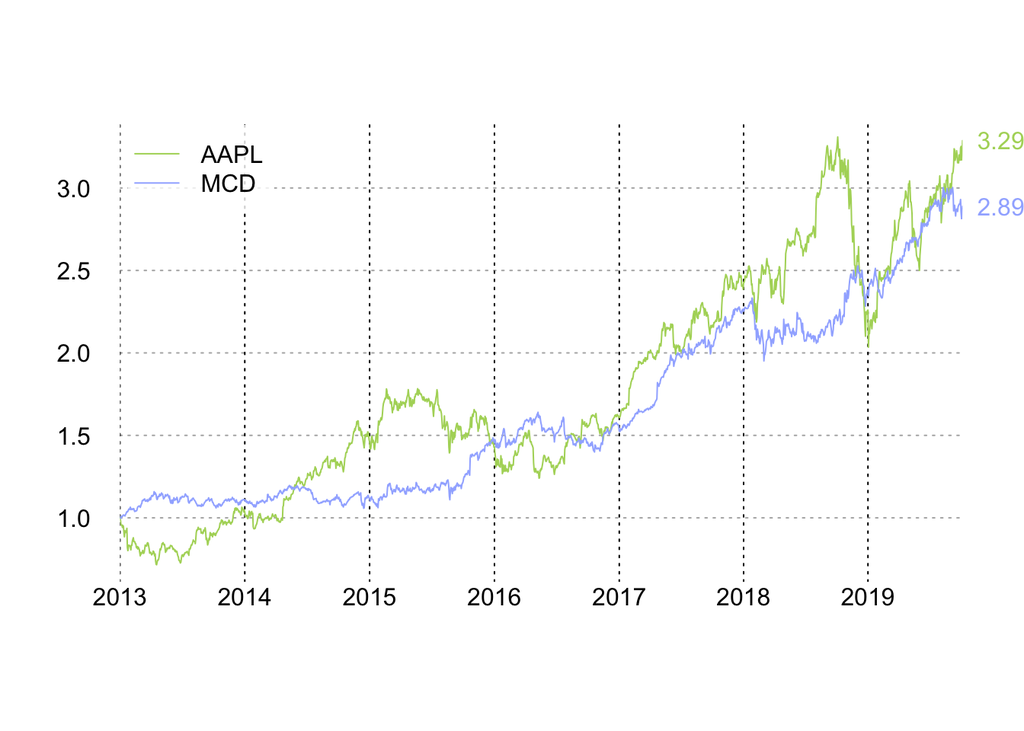

```r
# download data
stock_1 = get_yahoo_data( "AAPL", from = "2013-01-02", to = "2020-01-01" )
stock_2 = get_yahoo_data( "MCD" , from = "2013-01-02", to = "2020-01-01" )

# calс returns
stock_1 = stock_1[, .( date, return_1 = close / shift( close, fill = close[1] ) - 1 )]
stock_2 = stock_2[, .( date, return_2 = close / shift( close, fill = close[1] ) - 1 )]

# merge to portfolio
portfolio = merge( stock_1, stock_2, by = "date" )
data = as.vector( portfolio[, .( return_1, return_2 ) ] )

# pnl as cumulative products
plot_dts( portfolio[ , .(date, AAPL = cumprod(1+return_1), MCD = cumprod(1+return_2)) ] )
```

## Portfolio optimization

В этом разделе будет рассматриваться оптимизация портфеля по рыночным метрикам  
Будет рассмотрен вариант статической и динамической оптимизации  
Активно будет использоватьчя пакет data.table, подробнее его синтаксис можно изучить тут:  
https://cran.r-project.org/web/packages/data.table/vignettes/datatable-intro.html

### Статическая оптимизация

Напишем функцию для расчета статистики

```r
calc_perfomance = function( returns ){

  # Cumulative Products
  pnl = cumprod( returns + 1 )

  summary = data.table(
    pnl    = prod( returns + 1 ) - 1,
    max_dd = min( pnl / cummax( pnl ) - 1 ) * 100,
    sharpe = mean( returns ) / sd( returns ) * sqrt(252)
  )

  round( summary, 2 )

}
```

Посчитаем статистику наших акций

```r
calc_perfomance( portfolio$return_1 )
```

```
##     pnl max_dd sharpe
## 1: 2.39 -38.52   0.84
```

```r
calc_perfomance( portfolio$return_2 )
```

```
##     pnl max_dd sharpe
## 1: 1.95 -16.34    1.1
```

Определим сетку весов

```r
# weights
weights = CJ(
  w1 = seq( 0.0, 1, 0.05),
  w2 = seq( 0.0, 1, 0.05)
)
weights = weights[ w1+w2 == 1 ]
```

Посчитаем статистику для каждого набора весов

```r
result = weights[, calc_perfomance( portfolio$return_1*w1 + portfolio$return_2*w2  )
        , by = .( w1, w2 ) ]

result[order(-pnl)][1:5]
```

```
##      w1   w2  pnl max_dd sharpe
## 1: 0.70 0.30 2.42 -27.03   1.04
## 2: 0.75 0.25 2.42 -29.06   1.00
## 3: 0.80 0.20 2.42 -31.04   0.97
## 4: 0.85 0.15 2.42 -32.98   0.93
## 5: 0.90 0.10 2.42 -34.87   0.90
```

```r
result[order(-max_dd)][1:5]
```

```
##      w1   w2  pnl max_dd sharpe
## 1: 0.20 0.80 2.15 -12.69   1.23
## 2: 0.25 0.75 2.19 -13.56   1.25
## 3: 0.15 0.85 2.10 -13.61   1.21
## 4: 0.10 0.90 2.06 -14.53   1.18
## 5: 0.30 0.70 2.23 -14.70   1.25
```

```r
result[order(-sharpe)][1:5]
```

```
##      w1   w2  pnl max_dd sharpe
## 1: 0.25 0.75 2.19 -13.56   1.25
## 2: 0.30 0.70 2.23 -14.70   1.25
## 3: 0.35 0.65 2.27 -15.84   1.24
## 4: 0.20 0.80 2.15 -12.69   1.23
## 5: 0.40 0.60 2.30 -16.97   1.23
```

Выберем параметры для портфеля с равными весами, с макс доходностью, максимальном Sharpe

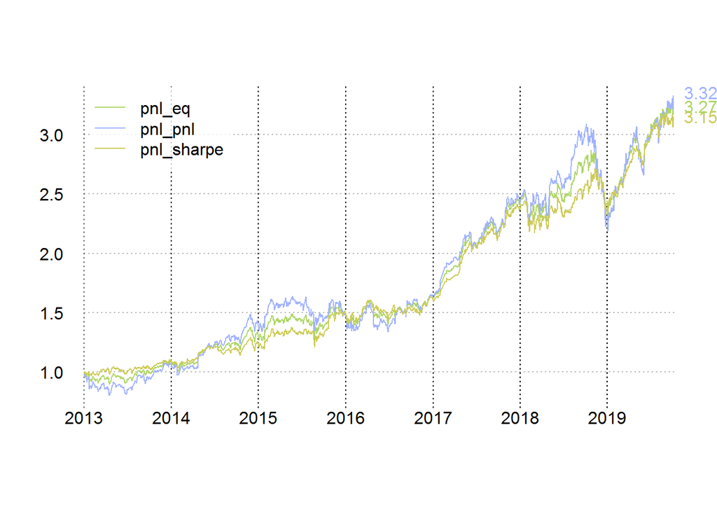

```r
# sum returns
portf_eq         = portfolio[, .(date, pnl_eq     = return_1*0.5 + return_2*0.5)   ]
portf_max_pnl    = portfolio[, .(date, pnl_pnl    = return_1*0.75 + return_2*0.25) ]
portf_max_sharpe = portfolio[, .(date, pnl_sharpe = return_1*0.30 + return_2*0.7 ) ]

# calc pnl
portf_eq        [, pnl_eq     := cumprod( 1 + pnl_eq)     ]
portf_max_pnl   [, pnl_pnl    := cumprod( 1 + pnl_pnl)    ]
portf_max_sharpe[, pnl_sharpe := cumprod( 1 + pnl_sharpe) ]

plot_dts(
  portf_eq,
  portf_max_pnl,
  portf_max_sharpe
)
```

### Динамическая оптимизация

Функция, оптимизирует веса по Sharpe. Можно также написать по любой другой характеристике

```r
calc_opt_weights = function( return_1, return_2 ){

  weights = CJ(
    w1 = seq( 0.05, 1, 0.05),
    w2 = seq( 0.05, 1, 0.05)
  )
  weights = weights[ w1+w2 == 1 ]

  weights = weights[, calc_perfomance( return_1*w1 + return_2*w2  )
          , by = .( w1, w2 ) ]

  weights[order(-sharpe)][1, .(w1, w2)]

}
```

Расчитаем оптимальные веса для каждого года

```r
portfolio[, year := year(date) ]
weights = portfolio[, calc_opt_weights( return_1, return_2 ), by = year ]
weights[, year := year + 1] # use this w for new year
weights
```

```
##    year   w1   w2
## 1: 2014 0.05 0.95
## 2: 2015 0.95 0.05
## 3: 2016 0.05 0.95
## 4: 2017 0.50 0.50
## 5: 2018 0.30 0.70
## 6: 2019 0.05 0.95
## 7: 2020 0.30 0.70
```

Посчитаем доходность для каждого года с учетом весов  
Определим баланс на конец каждого года, чтобы потом учесть в итоговом портфеле

```r
# calc pnl yearly
portfolio_dynamic = merge( portfolio, weights, by = "year", all.x = T )
portfolio_dynamic = portfolio_dynamic[ !is.na( w1 ) ]
portfolio_dynamic[, pnl_yearly := cumprod( return_1*w1 + return_2*w2 +1), by = year]

# calc balance
result_yearly = portfolio_dynamic[, .(balance_yeraly = pnl_yearly[.N]), by = year]
result_yearly[, balance_yeraly := shift( balance_yeraly, fill = 1 ) ]
result_yearly[, balance := cumprod( balance_yeraly )]
```

Добавляем баланс в итоговый портфель и считаем доходность

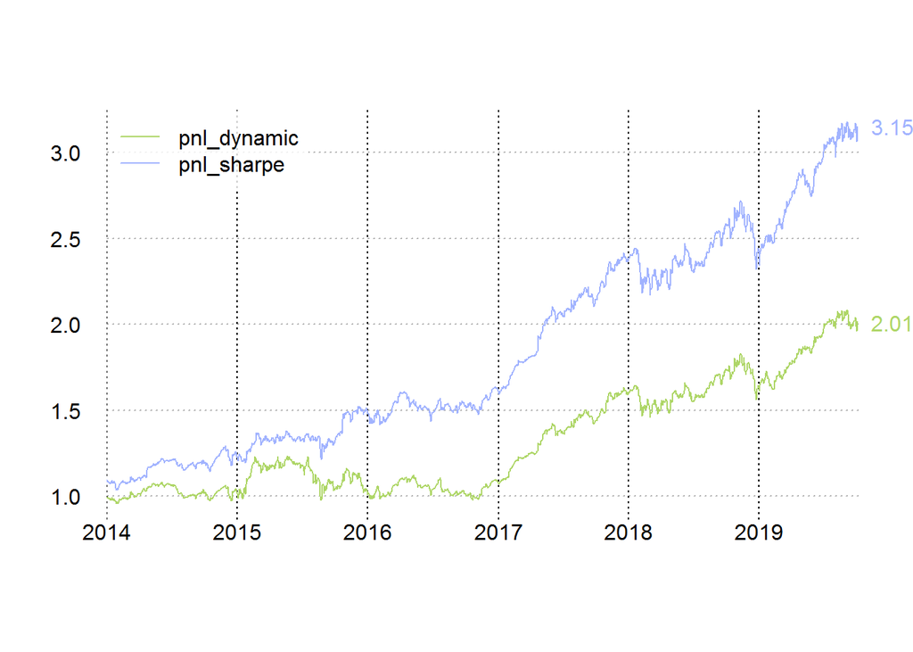

```r
# include balance for portf
portfolio_dynamic = merge( portfolio_dynamic, result_yearly, by = "year", all.x = T )
portfolio_dynamic[, pnl_dynamic := pnl_yearly * balance]


plot_dts(
  portfolio_dynamic[, .(date, pnl_dynamic)],
  portf_max_sharpe[year(date) >= 2014]
  )
```

## Оценка риска

В этом разделе будут рассмотрены варианты моделирования доходности портфеля и оценки риска

### ghyp

Выбираем лучшую модель

```r
aic.mv = stepAIC.ghyp( data, dist = c( "gauss", "t", "ghyp" ), symmetric=NULL, silent=T )
```

```
## Currently fitting: asymmetric t
## Currently fitting: asymmetric ghyp
## Currently fitting: symmetric t
## Currently fitting: symmetric ghyp
## Currently fitting: gauss
```

```r
aic.mv$best.model@model[1]
```

```
## [1] "Symmetric Student-t"
```

Подгоняем модель и считаем VaR и ES

```r
prt.fit = fit.tmv( data, symmetric=T, silent=T )

w     = c(0.5,0.5)
N     = 10^6
alpha = 0.05

sim = rghyp( n = N, object = prt.fit )
prt.sim = w[1] * sim[,1] + w[2] * sim[,2]
prt.sim = sort(prt.sim)

VaR = prt.sim[ alpha*N ]
ES  = mean( prt.sim[ 1:( alpha * N-1 ) ] )

data.table( VaR, ES )
```

```
##            VaR          ES
## 1: -0.01482457 -0.02315571
```

Пример оптимизации портфеля

```r
opt = portfolio.optimize(prt.fit, risk.measure= "value.at.risk",
                         type="minimum.risk", silent=T)
opt$opt.weights
```

```
## [1] 0.2105956 0.7894044
```

```r
w = opt$opt.weights
prt.sim = w[1]*sim[,1]+w[2]*sim[,2]
prt.sim = sort(prt.sim)

VaR = prt.sim[ alpha*N ]
ES  = mean( prt.sim[ 1:( alpha * N-1 ) ] )

data.table( VaR, ES )
```

```
##            VaR          ES
## 1: -0.01315003 -0.02051874
```

### copula

Выбираем лучшую модель для каждой бумаги

```r
stock1.fit = stepAIC.ghyp( data$return_1, dist = c( "gauss", "t", "ghyp" ),
                           symmetric=NULL, silent=T)$best.model
```

```
## Currently fitting: asymmetric t
## Currently fitting: asymmetric ghyp
## Currently fitting: symmetric t
## Currently fitting: symmetric ghyp
## Currently fitting: gauss
```

```r
stock2.fit = stepAIC.ghyp( data$return_2, dist = c( "gauss", "t", "ghyp" ),
                           symmetric=NULL, silent=T)$best.model
```

```
## Currently fitting: asymmetric t
## Currently fitting: asymmetric ghyp
## Currently fitting: symmetric t
## Currently fitting: symmetric ghyp
## Currently fitting: gauss
```

```r
stock1.fit@model[1]
```

```
## [1] "Symmetric Generalized Hyperbolic"
```

```r
stock2.fit@model[1]
```

```
## [1] "Symmetric Student-t"
```

Получаем эмперические распределения доходностей Строим совместное распределение

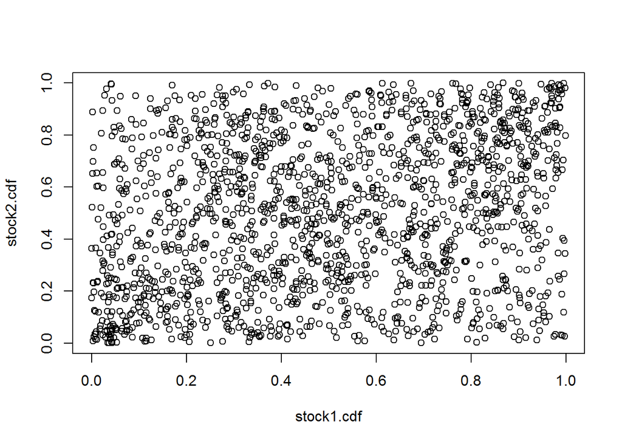

```r
stock1.cdf = pghyp( data$return_1, object = stock1.fit )
stock2.cdf = pghyp( data$return_2, object = stock2.fit )

cdf = cbind( stock1.cdf, stock2.cdf )
plot( cdf )
```

Подгоняем копулы и определяем лучшую модель

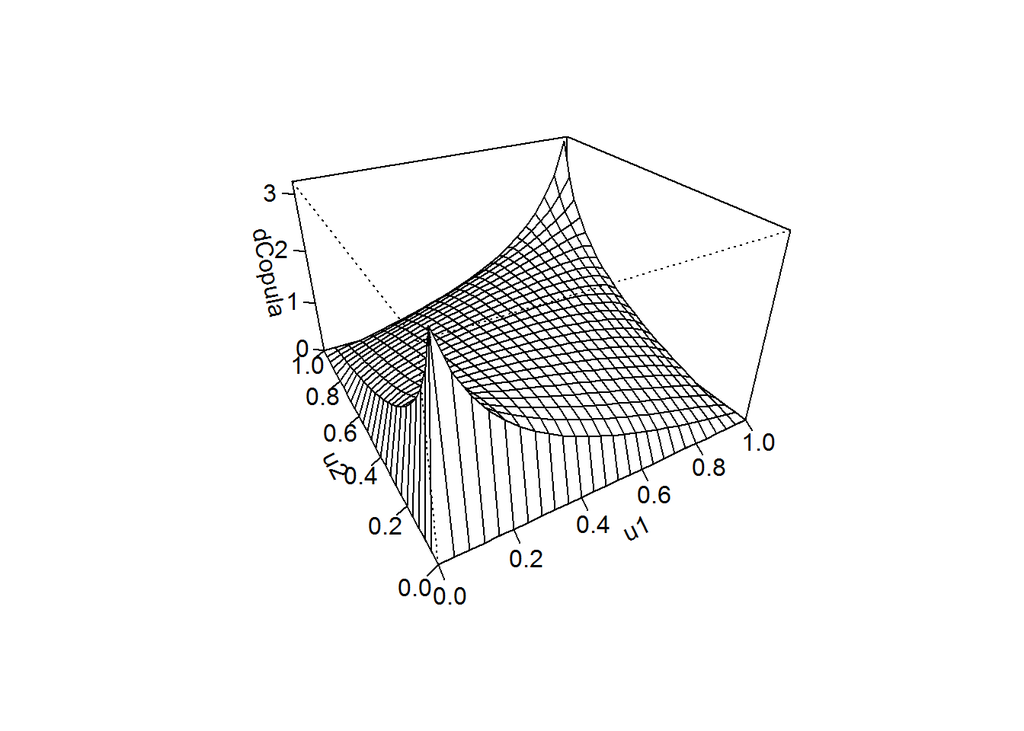

```r
# define copulas
norm.cop = normalCopula( dim=2, param=0.5, dispstr="un" )
stud.cop = tCopula     ( dim=2, param=0.5 )
gumb.cop = gumbelCopula( dim=2, param=2 )

# Copula plot
persp( norm.cop, dCopula )
```

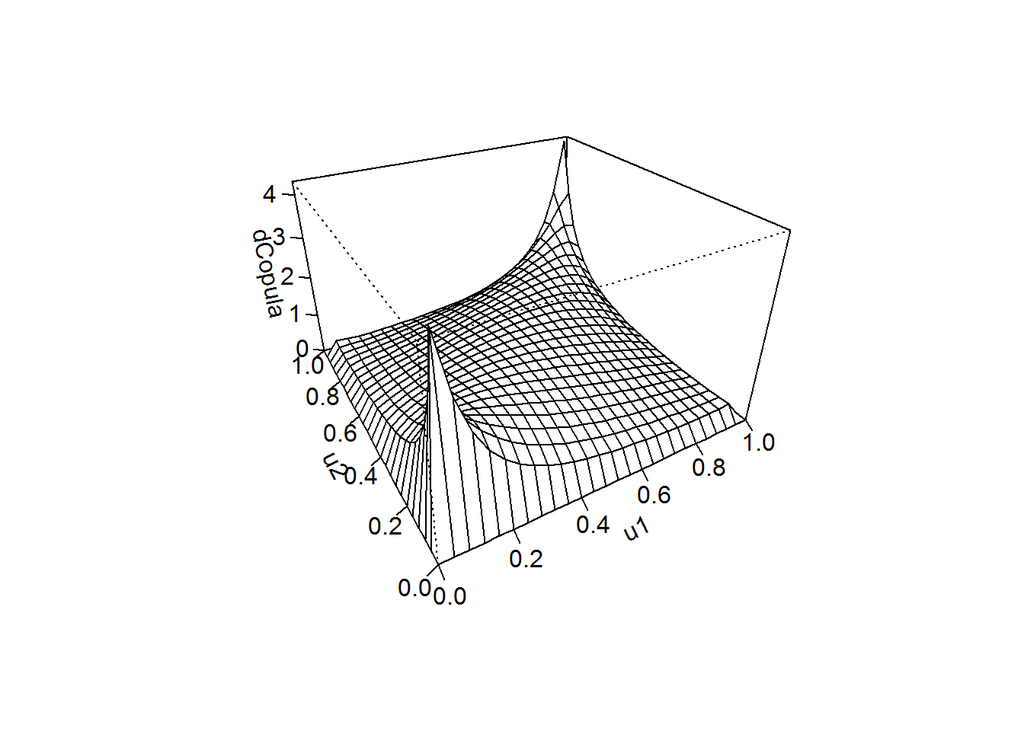

```r
persp( stud.cop, dCopula )
```

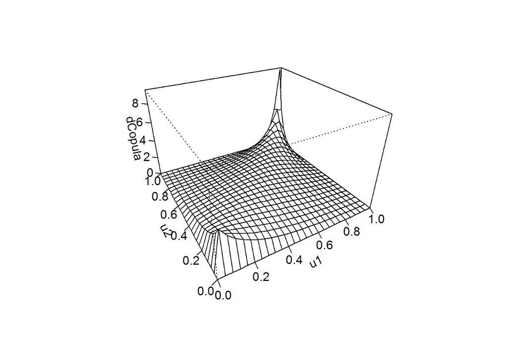

```r
persp( gumb.cop, dCopula )
```

```r
# Copula fiting
norm.fit = fitCopula(cdf,copula=norm.cop)
stud.fit = fitCopula(cdf,copula=stud.cop)
gumb.fit = fitCopula(cdf,copula=gumb.cop)

# best model
data.table(
norm = norm.fit@loglik,
stud = stud.fit@loglik,
gumb = gumb.fit@loglik
)
```

```
##       norm     stud     gumb
## 1: 60.9476 73.55393 61.19394
```

Считаем Var и ES

```r
N = 10^3
stud.sim = rCopula( n=N, copula = stud.fit@copula )

stock1.sim = qghyp( stud.sim[,1], object=stock1.fit )
stock2.sim = qghyp( stud.sim[,2], object=stock2.fit )

w = c(0.5,0.5)
prt.sim = w[1]*stock1.sim + w[2]*stock2.sim

alpha = 0.05
prt.sim = sort(prt.sim)
VaR = prt.sim[alpha*N]
ES = mean(prt.sim[1:(alpha*N-1)])

data.table( VaR, ES )
```

```
##            VaR          ES
## 1: -0.01418084 -0.02209495
```

### GARCH

Подгоняем GARCH модели, стандартизируем остатки и получаем распределение

```r
stock1.gfit = garchFit( data = data$return_1, formula =~garch(1,1),
                     cond.dist="ged", trace=F )

stock2.gfit = garchFit( data = data$return_2, formula =~garch(1,1),
                     cond.dist="ged", trace=F )

# stand residuals
z = matrix( nrow=nrow(data), ncol=2 )
z[,1] = stock1.gfit@residuals / stock1.gfit@sigma.t
z[,2] = stock2.gfit@residuals / stock2.gfit@sigma.t

# CDF for residuals
mean = c(0,0); sd = c(1,1); nu = c(1.3,1.3)
xi = c(1, 1 )
cdf = matrix( nrow=nrow(data), ncol=2 )

cdf[,1] = psged( z[,1], mean=mean[1], sd=sd[1], nu=nu[1], xi=xi[1] )
cdf[,2] = psged (z[,2], mean=mean[2], sd=sd[2], nu=nu[2], xi=xi[2] )
```

Подгонка копул

```r
# Copula fiting
norm.fit = fitCopula( cdf, copula=norm.cop )
stud.fit = fitCopula( cdf, copula=stud.cop )
gumb.fit = fitCopula( cdf, copula=gumb.cop )

# best model
data.table(
norm = norm.fit@loglik,
stud = stud.fit@loglik,
gumb = gumb.fit@loglik
)
```

```
##        norm     stud     gumb
## 1: 48.29756 50.30017 33.59729
```

Оцениваем риск

```r
cdf.sim = rCopula( n=N, copula=norm.fit@copula )
z.sim = matrix( nrow=N, ncol=2 )
for (i in 1:2)
  z.sim[,i] = qsged(cdf.sim[,i], mean=mean[i], sd=sd[i], nu=nu[i], xi=xi[i] )

frc1 = predict( stock1.gfit, n.ahead=1 )
frc2 = predict( stock2.gfit, n.ahead=1 )
mu = c(frc1[,1],frc2[,1])
sigma = c(frc1[,3],frc2[,3])


prt.sim = w[1]*(mu[1]+sigma[1]*z.sim[,1]) +
  w[2]*(mu[2]+sigma[2]*z.sim[,2])

prt.sim = sort(prt.sim)
VaR = prt.sim[alpha*N]
ES = mean(prt.sim[1:(alpha*N-1)])

data.table( VaR, ES )
```

```
##            VaR          ES
## 1: -0.01886081 -0.02504604
```

### Метод экстремальных значений

Рассмотрим случай для выборки значений, превышающих многомерный порог

Метод оценивает абсолютные значения, поэтому меняем знак у векторов доходности Выбираем значения, превышающих многомерный порог

```r
ESM = -as.matrix(data)

alpha = 1 - 0.10

T = nrow( data )
u = c(sort(ESM[,1])[alpha*T],sort(ESM[,2])[alpha*T])
t.ESM = ESM[ ( ESM[,1] > u[1] ) & ( ESM[,2] > u[2] ), ]
```

Подгоняем модели GPD и получаем значения частных функций

```r
fit1 = fpot( t.ESM[,1],threshold=u[1], model="gpd" )
fit2 = fpot( t.ESM[,2],threshold=u[2], model="gpd" )

# CDF
cdf1 = pgpd( t.ESM[,1],loc=u[1],scale=fit1$par[1], shape=fit1$par[2] )
cdf2 = pgpd( t.ESM[,2],loc=u[2],scale=fit2$par[1], shape=fit2$par[2] )
cdf = cbind( cdf1, cdf2 )
```

Подгонка копулы

```r
gumb.cop = gumbelCopula( dim=2, param = 2 )
gal.cop = galambosCopula( 2 )

gumb.fit = fitCopula( cdf, copula = gumb.cop )
#gal.fit  = fitCopula( cdf, copula = gal.cop  )

data.table(
gumb = gumb.fit@loglik#,
#gal  = gal.fit@loglik
)
```

```
##         gumb
## 1: 0.1661212
```

Моделируем значения и расчитываем меры риска

```r
cdf.sim = rCopula(n=N,copula=gumb.fit@copula)
sim1 = qgpd(cdf.sim[,1],loc=u[1],scale=fit1$par[1],
             shape=fit1$par[2])
sim2 = qgpd(cdf.sim[,2],loc=u[2],scale=fit2$par[1],
             shape=fit2$par[2])

loss = sort(w[1]*sim1+w[2]*sim2)

Fu = nrow(t.ESM)/T
alpha = 1-1/(260*Fu)
VaR = loss[alpha*N]
ES = mean(loss[(alpha*N+1):N])

data.table( -VaR, -ES )
```

```
##            V1          V2
## 1: -0.0310901 -0.03654396
```

ДЗ  
1. Оптимизировать портфель на двух бумагах, сделать динамическую оптимизацию.  
2. Оценить раск портфеля двух любых активов и провести тест Купика. Выбрать лучшую модель.